# Risk Factor Analysis

## Outcome Variable

**Outcome Variable:** ever_wasted

## Predictor Variables

**Intervention Variable:** vagbrth

**Adjustment Set:**

- arm
- sex
- W_mage
- meducyrs
- feducyrs
- hhwealth_quart
- W_mhtcm
- W_mwtkg
- W_mbmi
- single
- W_nrooms
- brthmon
- W_parity
- delta_W_mage
- delta_meducyrs
- delta_feducyrs
- delta_hhwealth_quart
- delta_W_mhtcm
- delta_W_mwtkg
- delta_W_mbmi
- delta_single
- delta_W_nrooms
- delta_brthmon
- delta_W_parity

## Stratifying Variables

The analysis was stratified on these variable(s):

- agecat
- studyid
- country

## Data Summary

| agecat | studyid | country | vagbrth | ever_wasted | n_cell | n |
| --- | --- | --- | --- | --- | --- | --- |
| 0-24 months (no birth wast) | CMC-V-BCS-2002 | INDIA | 0 | 0 | 17 | 368 |
| 0-24 months (no birth wast) | CMC-V-BCS-2002 | INDIA | 0 | 1 | 8 | 368 |
| 0-24 months (no birth wast) | CMC-V-BCS-2002 | INDIA | 1 | 0 | 185 | 368 |
| 0-24 months (no birth wast) | CMC-V-BCS-2002 | INDIA | 1 | 1 | 158 | 368 |
| 0-24 months (no birth wast) | IRC | INDIA | 0 | 0 | 38 | 409 |
| 0-24 months (no birth wast) | IRC | INDIA | 0 | 1 | 32 | 409 |
| 0-24 months (no birth wast) | IRC | INDIA | 1 | 0 | 158 | 409 |
| 0-24 months (no birth wast) | IRC | INDIA | 1 | 1 | 181 | 409 |
| 0-24 months (no birth wast) | JiVitA-3 | BANGLADESH | 0 | 0 | 1301 | 26404 |
| 0-24 months (no birth wast) | JiVitA-3 | BANGLADESH | 0 | 1 | 189 | 26404 |
| 0-24 months (no birth wast) | JiVitA-3 | BANGLADESH | 1 | 0 | 20624 | 26404 |
| 0-24 months (no birth wast) | JiVitA-3 | BANGLADESH | 1 | 1 | 4290 | 26404 |
| 0-24 months (no birth wast) | JiVitA-4 | BANGLADESH | 0 | 0 | 291 | 4499 |
| 0-24 months (no birth wast) | JiVitA-4 | BANGLADESH | 0 | 1 | 79 | 4499 |
| 0-24 months (no birth wast) | JiVitA-4 | BANGLADESH | 1 | 0 | 3007 | 4499 |
| 0-24 months (no birth wast) | JiVitA-4 | BANGLADESH | 1 | 1 | 1122 | 4499 |
| 0-24 months (no birth wast) | NIH-Crypto | BANGLADESH | 0 | 0 | 181 | 496 |
| 0-24 months (no birth wast) | NIH-Crypto | BANGLADESH | 0 | 1 | 21 | 496 |
| 0-24 months (no birth wast) | NIH-Crypto | BANGLADESH | 1 | 0 | 245 | 496 |
| 0-24 months (no birth wast) | NIH-Crypto | BANGLADESH | 1 | 1 | 49 | 496 |
| 0-24 months (no birth wast) | PROBIT | BELARUS | 0 | 0 | 1805 | 16879 |
| 0-24 months (no birth wast) | PROBIT | BELARUS | 0 | 1 | 147 | 16879 |
| 0-24 months (no birth wast) | PROBIT | BELARUS | 1 | 0 | 13926 | 16879 |
| 0-24 months (no birth wast) | PROBIT | BELARUS | 1 | 1 | 1001 | 16879 |
| 0-24 months (no birth wast) | PROVIDE | BANGLADESH | 0 | 0 | 132 | 687 |
| 0-24 months (no birth wast) | PROVIDE | BANGLADESH | 0 | 1 | 27 | 687 |
| 0-24 months (no birth wast) | PROVIDE | BANGLADESH | 1 | 0 | 433 | 687 |
| 0-24 months (no birth wast) | PROVIDE | BANGLADESH | 1 | 1 | 95 | 687 |
| 0-24 months (no birth wast) | TanzaniaChild2 | TANZANIA, UNITED REPUBLIC OF | 0 | 0 | 174 | 2355 |
| 0-24 months (no birth wast) | TanzaniaChild2 | TANZANIA, UNITED REPUBLIC OF | 0 | 1 | 38 | 2355 |
| 0-24 months (no birth wast) | TanzaniaChild2 | TANZANIA, UNITED REPUBLIC OF | 1 | 0 | 1712 | 2355 |
| 0-24 months (no birth wast) | TanzaniaChild2 | TANZANIA, UNITED REPUBLIC OF | 1 | 1 | 431 | 2355 |
| 0-24 months (no birth wast) | ZVITAMBO | ZIMBABWE | 0 | 0 | 1042 | 13522 |
| 0-24 months (no birth wast) | ZVITAMBO | ZIMBABWE | 0 | 1 | 100 | 13522 |
| 0-24 months (no birth wast) | ZVITAMBO | ZIMBABWE | 1 | 0 | 11104 | 13522 |
| 0-24 months (no birth wast) | ZVITAMBO | ZIMBABWE | 1 | 1 | 1276 | 13522 |
| 0-6 months (no birth wast) | CMC-V-BCS-2002 | INDIA | 0 | 0 | 15 | 350 |
| 0-6 months (no birth wast) | CMC-V-BCS-2002 | INDIA | 0 | 1 | 8 | 350 |
| 0-6 months (no birth wast) | CMC-V-BCS-2002 | INDIA | 1 | 0 | 227 | 350 |
| 0-6 months (no birth wast) | CMC-V-BCS-2002 | INDIA | 1 | 1 | 100 | 350 |
| 0-6 months (no birth wast) | IRC | INDIA | 0 | 0 | 42 | 390 |
| 0-6 months (no birth wast) | IRC | INDIA | 0 | 1 | 25 | 390 |
| 0-6 months (no birth wast) | IRC | INDIA | 1 | 0 | 215 | 390 |
| 0-6 months (no birth wast) | IRC | INDIA | 1 | 1 | 108 | 390 |
| 0-6 months (no birth wast) | JiVitA-3 | BANGLADESH | 0 | 0 | 1387 | 26154 |
| 0-6 months (no birth wast) | JiVitA-3 | BANGLADESH | 0 | 1 | 71 | 26154 |
| 0-6 months (no birth wast) | JiVitA-3 | BANGLADESH | 1 | 0 | 22889 | 26154 |
| 0-6 months (no birth wast) | JiVitA-3 | BANGLADESH | 1 | 1 | 1807 | 26154 |
| 0-6 months (no birth wast) | JiVitA-4 | BANGLADESH | 0 | 0 | 347 | 4380 |
| 0-6 months (no birth wast) | JiVitA-4 | BANGLADESH | 0 | 1 | 11 | 4380 |
| 0-6 months (no birth wast) | JiVitA-4 | BANGLADESH | 1 | 0 | 3907 | 4380 |
| 0-6 months (no birth wast) | JiVitA-4 | BANGLADESH | 1 | 1 | 115 | 4380 |
| 0-6 months (no birth wast) | NIH-Crypto | BANGLADESH | 0 | 0 | 199 | 493 |
| 0-6 months (no birth wast) | NIH-Crypto | BANGLADESH | 0 | 1 | 3 | 493 |
| 0-6 months (no birth wast) | NIH-Crypto | BANGLADESH | 1 | 0 | 282 | 493 |
| 0-6 months (no birth wast) | NIH-Crypto | BANGLADESH | 1 | 1 | 9 | 493 |
| 0-6 months (no birth wast) | PROBIT | BELARUS | 0 | 0 | 1805 | 16693 |
| 0-6 months (no birth wast) | PROBIT | BELARUS | 0 | 1 | 131 | 16693 |
| 0-6 months (no birth wast) | PROBIT | BELARUS | 1 | 0 | 13866 | 16693 |
| 0-6 months (no birth wast) | PROBIT | BELARUS | 1 | 1 | 891 | 16693 |
| 0-6 months (no birth wast) | PROVIDE | BANGLADESH | 0 | 0 | 146 | 683 |
| 0-6 months (no birth wast) | PROVIDE | BANGLADESH | 0 | 1 | 12 | 683 |
| 0-6 months (no birth wast) | PROVIDE | BANGLADESH | 1 | 0 | 500 | 683 |
| 0-6 months (no birth wast) | PROVIDE | BANGLADESH | 1 | 1 | 25 | 683 |
| 0-6 months (no birth wast) | TanzaniaChild2 | TANZANIA, UNITED REPUBLIC OF | 0 | 0 | 198 | 2347 |
| 0-6 months (no birth wast) | TanzaniaChild2 | TANZANIA, UNITED REPUBLIC OF | 0 | 1 | 13 | 2347 |
| 0-6 months (no birth wast) | TanzaniaChild2 | TANZANIA, UNITED REPUBLIC OF | 1 | 0 | 1947 | 2347 |
| 0-6 months (no birth wast) | TanzaniaChild2 | TANZANIA, UNITED REPUBLIC OF | 1 | 1 | 189 | 2347 |
| 0-6 months (no birth wast) | ZVITAMBO | ZIMBABWE | 0 | 0 | 1107 | 13264 |
| 0-6 months (no birth wast) | ZVITAMBO | ZIMBABWE | 0 | 1 | 22 | 13264 |
| 0-6 months (no birth wast) | ZVITAMBO | ZIMBABWE | 1 | 0 | 11731 | 13264 |
| 0-6 months (no birth wast) | ZVITAMBO | ZIMBABWE | 1 | 1 | 404 | 13264 |

The following strata were considered:

- agecat: 0-24 months (no birth wast), studyid: CMC-V-BCS-2002, country: INDIA
- agecat: 0-24 months (no birth wast), studyid: IRC, country: INDIA
- agecat: 0-24 months (no birth wast), studyid: JiVitA-3, country: BANGLADESH
- agecat: 0-24 months (no birth wast), studyid: JiVitA-4, country: BANGLADESH
- agecat: 0-24 months (no birth wast), studyid: NIH-Crypto, country: BANGLADESH
- agecat: 0-24 months (no birth wast), studyid: PROBIT, country: BELARUS
- agecat: 0-24 months (no birth wast), studyid: PROVIDE, country: BANGLADESH
- agecat: 0-24 months (no birth wast), studyid: TanzaniaChild2, country: TANZANIA, UNITED REPUBLIC OF
- agecat: 0-24 months (no birth wast), studyid: ZVITAMBO, country: ZIMBABWE
- agecat: 0-6 months (no birth wast), studyid: CMC-V-BCS-2002, country: INDIA
- agecat: 0-6 months (no birth wast), studyid: IRC, country: INDIA
- agecat: 0-6 months (no birth wast), studyid: JiVitA-3, country: BANGLADESH
- agecat: 0-6 months (no birth wast), studyid: JiVitA-4, country: BANGLADESH
- agecat: 0-6 months (no birth wast), studyid: NIH-Crypto, country: BANGLADESH
- agecat: 0-6 months (no birth wast), studyid: PROBIT, country: BELARUS
- agecat: 0-6 months (no birth wast), studyid: PROVIDE, country: BANGLADESH
- agecat: 0-6 months (no birth wast), studyid: TanzaniaChild2, country: TANZANIA, UNITED REPUBLIC OF
- agecat: 0-6 months (no birth wast), studyid: ZVITAMBO, country: ZIMBABWE

### Dropped Strata

Some strata were dropped due to rare outcomes:

- agecat: 0-6 months (no birth wast), studyid: NIH-Crypto, country: BANGLADESH

## Methods Detail

We're interested in the causal parameters $E[Y_a]$ for all values of $a \in \mathcal{A}$. These parameters represent the mean outcome if, possibly contrary to fact, we intervened to set all units to have $A=a$. Under the randomization and positivity assumptions, these are identified by the statistical parameters $\psi_a=E_W[E_{Y|A,W}(Y|A=a,W)]$. In addition, we're interested in the mean of $Y$, $E[Y]$ under no intervention (the observed mean). We will estimate these parameters by using SuperLearner to fit the relevant likelihood factors -- $E_{Y|A,W}(Y|A=a,W)$ and $p(A=a|W)$, and then updating our likelihood fit using a joint TMLE.

For unadjusted analyses ($W=\{\}$), initial likelihoods were estimated using Lrnr_glm to estimate the simple $E(Y|A)$ and Lrnr_mean to estimate $p(A)$. For adjusted analyses, a small library containing Lrnr_glmnet, Lrnr_xgboost, and Lrnr_mean was used.

Having estimated these parameters, we will then use the delta method to estimate relative risks and attributable risks relative to a prespecified baseline level of $A$.

# Results Detail

## Results Plots

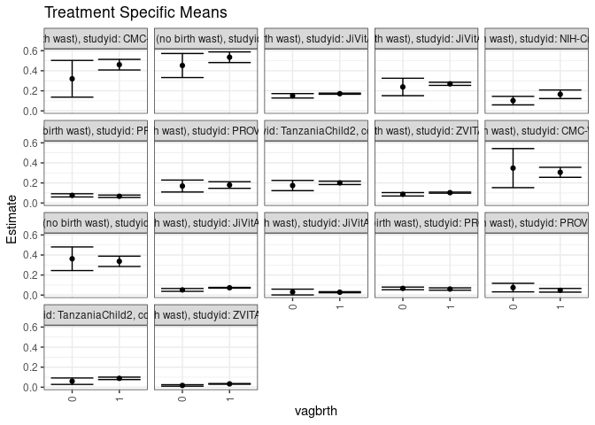

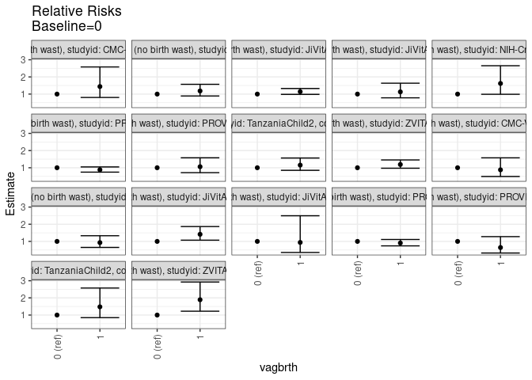

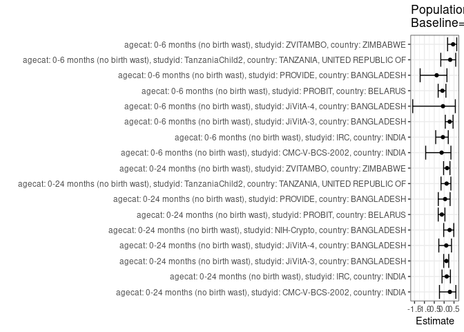

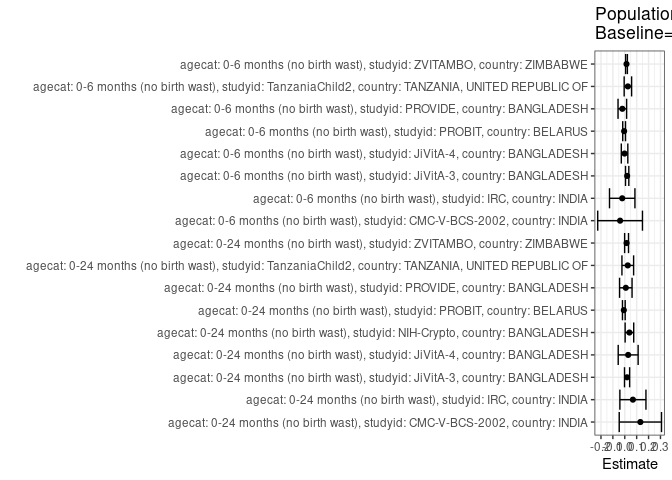

## Results Table

### Parameter: TSM

| agecat | studyid | country | intervention_level | baseline_level | estimate | ci_lower | ci_upper |
| --- | --- | --- | --- | --- | --- | --- | --- |
| 0-24 months (no birth wast) | CMC-V-BCS-2002 | INDIA | 0 | NA | 0.3200000 | 0.1368958 | 0.5031042 |
| 0-24 months (no birth wast) | CMC-V-BCS-2002 | INDIA | 1 | NA | 0.4606414 | 0.4078197 | 0.5134631 |
| 0-24 months (no birth wast) | IRC | INDIA | 0 | NA | 0.4523560 | 0.3323358 | 0.5723762 |
| 0-24 months (no birth wast) | IRC | INDIA | 1 | NA | 0.5348730 | 0.4817150 | 0.5880310 |
| 0-24 months (no birth wast) | JiVitA-3 | BANGLADESH | 0 | NA | 0.1502003 | 0.1281439 | 0.1722567 |
| 0-24 months (no birth wast) | JiVitA-3 | BANGLADESH | 1 | NA | 0.1714691 | 0.1659961 | 0.1769421 |
| 0-24 months (no birth wast) | JiVitA-4 | BANGLADESH | 0 | NA | 0.2383597 | 0.1513640 | 0.3253554 |
| 0-24 months (no birth wast) | JiVitA-4 | BANGLADESH | 1 | NA | 0.2694758 | 0.2539324 | 0.2850192 |
| 0-24 months (no birth wast) | NIH-Crypto | BANGLADESH | 0 | NA | 0.1020332 | 0.0595046 | 0.1445617 |
| 0-24 months (no birth wast) | NIH-Crypto | BANGLADESH | 1 | NA | 0.1652042 | 0.1224273 | 0.2079810 |
| 0-24 months (no birth wast) | PROBIT | BELARUS | 0 | NA | 0.0759646 | 0.0601311 | 0.0917981 |
| 0-24 months (no birth wast) | PROBIT | BELARUS | 1 | NA | 0.0669999 | 0.0550569 | 0.0789430 |
| 0-24 months (no birth wast) | PROVIDE | BANGLADESH | 0 | NA | 0.1688080 | 0.1093003 | 0.2283158 |
| 0-24 months (no birth wast) | PROVIDE | BANGLADESH | 1 | NA | 0.1790357 | 0.1462260 | 0.2118453 |
| 0-24 months (no birth wast) | TanzaniaChild2 | TANZANIA, UNITED REPUBLIC OF | 0 | NA | 0.1739019 | 0.1228065 | 0.2249973 |
| 0-24 months (no birth wast) | TanzaniaChild2 | TANZANIA, UNITED REPUBLIC OF | 1 | NA | 0.2006383 | 0.1836783 | 0.2175982 |
| 0-24 months (no birth wast) | ZVITAMBO | ZIMBABWE | 0 | NA | 0.0866158 | 0.0696808 | 0.1035509 |
| 0-24 months (no birth wast) | ZVITAMBO | ZIMBABWE | 1 | NA | 0.1029654 | 0.0976142 | 0.1083165 |
| 0-6 months (no birth wast) | CMC-V-BCS-2002 | INDIA | 0 | NA | 0.3478261 | 0.1529008 | 0.5427514 |
| 0-6 months (no birth wast) | CMC-V-BCS-2002 | INDIA | 1 | NA | 0.3058104 | 0.2558000 | 0.3558208 |
| 0-6 months (no birth wast) | IRC | INDIA | 0 | NA | 0.3624702 | 0.2448412 | 0.4800992 |
| 0-6 months (no birth wast) | IRC | INDIA | 1 | NA | 0.3368702 | 0.2852712 | 0.3884692 |
| 0-6 months (no birth wast) | JiVitA-3 | BANGLADESH | 0 | NA | 0.0516184 | 0.0374112 | 0.0658256 |
| 0-6 months (no birth wast) | JiVitA-3 | BANGLADESH | 1 | NA | 0.0729764 | 0.0691933 | 0.0767596 |
| 0-6 months (no birth wast) | JiVitA-4 | BANGLADESH | 0 | NA | 0.0304514 | 0.0015234 | 0.0593794 |
| 0-6 months (no birth wast) | JiVitA-4 | BANGLADESH | 1 | NA | 0.0286192 | 0.0232835 | 0.0339548 |
| 0-6 months (no birth wast) | PROBIT | BELARUS | 0 | NA | 0.0666567 | 0.0532844 | 0.0800290 |
| 0-6 months (no birth wast) | PROBIT | BELARUS | 1 | NA | 0.0603881 | 0.0488772 | 0.0718990 |
| 0-6 months (no birth wast) | PROVIDE | BANGLADESH | 0 | NA | 0.0746684 | 0.0320604 | 0.1172763 |
| 0-6 months (no birth wast) | PROVIDE | BANGLADESH | 1 | NA | 0.0479411 | 0.0295714 | 0.0663108 |
| 0-6 months (no birth wast) | TanzaniaChild2 | TANZANIA, UNITED REPUBLIC OF | 0 | NA | 0.0598664 | 0.0276937 | 0.0920392 |
| 0-6 months (no birth wast) | TanzaniaChild2 | TANZANIA, UNITED REPUBLIC OF | 1 | NA | 0.0885359 | 0.0764804 | 0.1005915 |
| 0-6 months (no birth wast) | ZVITAMBO | ZIMBABWE | 0 | NA | 0.0175228 | 0.0100866 | 0.0249591 |
| 0-6 months (no birth wast) | ZVITAMBO | ZIMBABWE | 1 | NA | 0.0331598 | 0.0299746 | 0.0363449 |

### Parameter: E(Y)

| agecat | studyid | country | intervention_level | baseline_level | estimate | ci_lower | ci_upper |
| --- | --- | --- | --- | --- | --- | --- | --- |
| 0-24 months (no birth wast) | CMC-V-BCS-2002 | INDIA | NA | NA | 0.4510870 | 0.4001777 | 0.5019962 |
| 0-24 months (no birth wast) | IRC | INDIA | NA | NA | 0.5207824 | 0.4723080 | 0.5692568 |
| 0-24 months (no birth wast) | JiVitA-3 | BANGLADESH | NA | NA | 0.1696334 | 0.1643208 | 0.1749460 |
| 0-24 months (no birth wast) | JiVitA-4 | BANGLADESH | NA | NA | 0.2669482 | 0.2519234 | 0.2819730 |
| 0-24 months (no birth wast) | NIH-Crypto | BANGLADESH | NA | NA | 0.1411290 | 0.1104588 | 0.1717993 |
| 0-24 months (no birth wast) | PROBIT | BELARUS | NA | NA | 0.0680135 | 0.0562135 | 0.0798135 |
| 0-24 months (no birth wast) | PROVIDE | BANGLADESH | NA | NA | 0.1775837 | 0.1489858 | 0.2061816 |
| 0-24 months (no birth wast) | TanzaniaChild2 | TANZANIA, UNITED REPUBLIC OF | NA | NA | 0.1991507 | 0.1830179 | 0.2152836 |
| 0-24 months (no birth wast) | ZVITAMBO | ZIMBABWE | NA | NA | 0.1017601 | 0.0966641 | 0.1068561 |
| 0-6 months (no birth wast) | CMC-V-BCS-2002 | INDIA | NA | NA | 0.3085714 | 0.2601110 | 0.3570318 |
| 0-6 months (no birth wast) | IRC | INDIA | NA | NA | 0.3410256 | 0.2939169 | 0.3881343 |
| 0-6 months (no birth wast) | JiVitA-3 | BANGLADESH | NA | NA | 0.0718055 | 0.0681632 | 0.0754477 |
| 0-6 months (no birth wast) | JiVitA-4 | BANGLADESH | NA | NA | 0.0287671 | 0.0234680 | 0.0340662 |
| 0-6 months (no birth wast) | PROBIT | BELARUS | NA | NA | 0.0612233 | 0.0502388 | 0.0722078 |
| 0-6 months (no birth wast) | PROVIDE | BANGLADESH | NA | NA | 0.0541728 | 0.0371844 | 0.0711612 |
| 0-6 months (no birth wast) | TanzaniaChild2 | TANZANIA, UNITED REPUBLIC OF | NA | NA | 0.0860673 | 0.0747182 | 0.0974164 |
| 0-6 months (no birth wast) | ZVITAMBO | ZIMBABWE | NA | NA | 0.0321170 | 0.0291164 | 0.0351176 |

### Parameter: RR

| agecat | studyid | country | intervention_level | baseline_level | estimate | ci_lower | ci_upper |
| --- | --- | --- | --- | --- | --- | --- | --- |
| 0-24 months (no birth wast) | CMC-V-BCS-2002 | INDIA | 0 | 0 | 1.0000000 | 1.0000000 | 1.000000 |
| 0-24 months (no birth wast) | CMC-V-BCS-2002 | INDIA | 1 | 0 | 1.4395044 | 0.8030978 | 2.580225 |
| 0-24 months (no birth wast) | IRC | INDIA | 0 | 0 | 1.0000000 | 1.0000000 | 1.000000 |
| 0-24 months (no birth wast) | IRC | INDIA | 1 | 0 | 1.1824160 | 0.8906894 | 1.569692 |
| 0-24 months (no birth wast) | JiVitA-3 | BANGLADESH | 0 | 0 | 1.0000000 | 1.0000000 | 1.000000 |
| 0-24 months (no birth wast) | JiVitA-3 | BANGLADESH | 1 | 0 | 1.1416026 | 0.9837470 | 1.324788 |
| 0-24 months (no birth wast) | JiVitA-4 | BANGLADESH | 0 | 0 | 1.0000000 | 1.0000000 | 1.000000 |
| 0-24 months (no birth wast) | JiVitA-4 | BANGLADESH | 1 | 0 | 1.1305424 | 0.7819161 | 1.634608 |
| 0-24 months (no birth wast) | NIH-Crypto | BANGLADESH | 0 | 0 | 1.0000000 | 1.0000000 | 1.000000 |
| 0-24 months (no birth wast) | NIH-Crypto | BANGLADESH | 1 | 0 | 1.6191226 | 0.9888624 | 2.651085 |
| 0-24 months (no birth wast) | PROBIT | BELARUS | 0 | 0 | 1.0000000 | 1.0000000 | 1.000000 |
| 0-24 months (no birth wast) | PROBIT | BELARUS | 1 | 0 | 0.8819889 | 0.7431759 | 1.046730 |
| 0-24 months (no birth wast) | PROVIDE | BANGLADESH | 0 | 0 | 1.0000000 | 1.0000000 | 1.000000 |
| 0-24 months (no birth wast) | PROVIDE | BANGLADESH | 1 | 0 | 1.0605872 | 0.7127122 | 1.578260 |
| 0-24 months (no birth wast) | TanzaniaChild2 | TANZANIA, UNITED REPUBLIC OF | 0 | 0 | 1.0000000 | 1.0000000 | 1.000000 |
| 0-24 months (no birth wast) | TanzaniaChild2 | TANZANIA, UNITED REPUBLIC OF | 1 | 0 | 1.1537438 | 0.8499510 | 1.566119 |
| 0-24 months (no birth wast) | ZVITAMBO | ZIMBABWE | 0 | 0 | 1.0000000 | 1.0000000 | 1.000000 |
| 0-24 months (no birth wast) | ZVITAMBO | ZIMBABWE | 1 | 0 | 1.1887589 | 0.9711676 | 1.455102 |
| 0-6 months (no birth wast) | CMC-V-BCS-2002 | INDIA | 0 | 0 | 1.0000000 | 1.0000000 | 1.000000 |
| 0-6 months (no birth wast) | CMC-V-BCS-2002 | INDIA | 1 | 0 | 0.8792049 | 0.4904064 | 1.576246 |
| 0-6 months (no birth wast) | IRC | INDIA | 0 | 0 | 1.0000000 | 1.0000000 | 1.000000 |
| 0-6 months (no birth wast) | IRC | INDIA | 1 | 0 | 0.9293735 | 0.6491410 | 1.330582 |
| 0-6 months (no birth wast) | JiVitA-3 | BANGLADESH | 0 | 0 | 1.0000000 | 1.0000000 | 1.000000 |
| 0-6 months (no birth wast) | JiVitA-3 | BANGLADESH | 1 | 0 | 1.4137686 | 1.0720576 | 1.864398 |
| 0-6 months (no birth wast) | JiVitA-4 | BANGLADESH | 0 | 0 | 1.0000000 | 1.0000000 | 1.000000 |
| 0-6 months (no birth wast) | JiVitA-4 | BANGLADESH | 1 | 0 | 0.9398315 | 0.3541985 | 2.493752 |
| 0-6 months (no birth wast) | PROBIT | BELARUS | 0 | 0 | 1.0000000 | 1.0000000 | 1.000000 |
| 0-6 months (no birth wast) | PROBIT | BELARUS | 1 | 0 | 0.9059567 | 0.7386590 | 1.111145 |
| 0-6 months (no birth wast) | PROVIDE | BANGLADESH | 0 | 0 | 1.0000000 | 1.0000000 | 1.000000 |
| 0-6 months (no birth wast) | PROVIDE | BANGLADESH | 1 | 0 | 0.6420537 | 0.3226520 | 1.277639 |
| 0-6 months (no birth wast) | TanzaniaChild2 | TANZANIA, UNITED REPUBLIC OF | 0 | 0 | 1.0000000 | 1.0000000 | 1.000000 |
| 0-6 months (no birth wast) | TanzaniaChild2 | TANZANIA, UNITED REPUBLIC OF | 1 | 0 | 1.4788914 | 0.8496470 | 2.574151 |
| 0-6 months (no birth wast) | ZVITAMBO | ZIMBABWE | 0 | 0 | 1.0000000 | 1.0000000 | 1.000000 |
| 0-6 months (no birth wast) | ZVITAMBO | ZIMBABWE | 1 | 0 | 1.8923742 | 1.2247535 | 2.923919 |

### Parameter: PAR

| agecat | studyid | country | intervention_level | baseline_level | estimate | ci_lower | ci_upper |
| --- | --- | --- | --- | --- | --- | --- | --- |
| 0-24 months (no birth wast) | CMC-V-BCS-2002 | INDIA | 0 | NA | 0.1310870 | -0.0465745 | 0.3087484 |
| 0-24 months (no birth wast) | IRC | INDIA | 0 | NA | 0.0684264 | -0.0411472 | 0.1780000 |
| 0-24 months (no birth wast) | JiVitA-3 | BANGLADESH | 0 | NA | 0.0194331 | -0.0021289 | 0.0409950 |
| 0-24 months (no birth wast) | JiVitA-4 | BANGLADESH | 0 | NA | 0.0285885 | -0.0551429 | 0.1123199 |
| 0-24 months (no birth wast) | NIH-Crypto | BANGLADESH | 0 | NA | 0.0390959 | 0.0030388 | 0.0751530 |
| 0-24 months (no birth wast) | PROBIT | BELARUS | 0 | NA | -0.0079511 | -0.0193096 | 0.0034074 |
| 0-24 months (no birth wast) | PROVIDE | BANGLADESH | 0 | NA | 0.0087757 | -0.0436766 | 0.0612279 |
| 0-24 months (no birth wast) | TanzaniaChild2 | TANZANIA, UNITED REPUBLIC OF | 0 | NA | 0.0252488 | -0.0238168 | 0.0743144 |
| 0-24 months (no birth wast) | ZVITAMBO | ZIMBABWE | 0 | NA | 0.0151443 | -0.0012055 | 0.0314940 |
| 0-6 months (no birth wast) | CMC-V-BCS-2002 | INDIA | 0 | NA | -0.0392547 | -0.2272721 | 0.1487628 |
| 0-6 months (no birth wast) | IRC | INDIA | 0 | NA | -0.0214446 | -0.1282220 | 0.0853329 |
| 0-6 months (no birth wast) | JiVitA-3 | BANGLADESH | 0 | NA | 0.0201871 | 0.0063292 | 0.0340449 |
| 0-6 months (no birth wast) | JiVitA-4 | BANGLADESH | 0 | NA | -0.0016843 | -0.0290261 | 0.0256576 |
| 0-6 months (no birth wast) | PROBIT | BELARUS | 0 | NA | -0.0054334 | -0.0170681 | 0.0062012 |
| 0-6 months (no birth wast) | PROVIDE | BANGLADESH | 0 | NA | -0.0204956 | -0.0565613 | 0.0155701 |
| 0-6 months (no birth wast) | TanzaniaChild2 | TANZANIA, UNITED REPUBLIC OF | 0 | NA | 0.0262009 | -0.0050820 | 0.0574838 |
| 0-6 months (no birth wast) | ZVITAMBO | ZIMBABWE | 0 | NA | 0.0145942 | 0.0072236 | 0.0219648 |

### Parameter: PAF

| agecat | studyid | country | intervention_level | baseline_level | estimate | ci_lower | ci_upper |
| --- | --- | --- | --- | --- | --- | --- | --- |
| 0-24 months (no birth wast) | CMC-V-BCS-2002 | INDIA | 0 | NA | 0.2906024 | -0.2363609 | 0.5929627 |
| 0-24 months (no birth wast) | IRC | INDIA | 0 | NA | 0.1313915 | -0.1072055 | 0.3185720 |
| 0-24 months (no birth wast) | JiVitA-3 | BANGLADESH | 0 | NA | 0.1145591 | -0.0220642 | 0.2329195 |
| 0-24 months (no birth wast) | JiVitA-4 | BANGLADESH | 0 | NA | 0.1070938 | -0.2699290 | 0.3721842 |
| 0-24 months (no birth wast) | NIH-Crypto | BANGLADESH | 0 | NA | 0.2770222 | -0.0227467 | 0.4889283 |
| 0-24 months (no birth wast) | PROBIT | BELARUS | 0 | NA | -0.1169047 | -0.2999939 | 0.0403984 |
| 0-24 months (no birth wast) | PROVIDE | BANGLADESH | 0 | NA | 0.0494170 | -0.2970289 | 0.3033246 |
| 0-24 months (no birth wast) | TanzaniaChild2 | TANZANIA, UNITED REPUBLIC OF | 0 | NA | 0.1267824 | -0.1576553 | 0.3413333 |
| 0-24 months (no birth wast) | ZVITAMBO | ZIMBABWE | 0 | NA | 0.1488231 | -0.0278694 | 0.2951419 |
| 0-6 months (no birth wast) | CMC-V-BCS-2002 | INDIA | 0 | NA | -0.1272142 | -0.9353750 | 0.3434803 |
| 0-6 months (no birth wast) | IRC | INDIA | 0 | NA | -0.0628825 | -0.4269013 | 0.2082709 |
| 0-6 months (no birth wast) | JiVitA-3 | BANGLADESH | 0 | NA | 0.2811358 | 0.0597060 | 0.4504210 |
| 0-6 months (no birth wast) | JiVitA-4 | BANGLADESH | 0 | NA | -0.0585485 | -1.5926678 | 0.5678101 |
| 0-6 months (no birth wast) | PROBIT | BELARUS | 0 | NA | -0.0887479 | -0.3028235 | 0.0901515 |
| 0-6 months (no birth wast) | PROVIDE | BANGLADESH | 0 | NA | -0.3783375 | -1.2157853 | 0.1426000 |
| 0-6 months (no birth wast) | TanzaniaChild2 | TANZANIA, UNITED REPUBLIC OF | 0 | NA | 0.3044233 | -0.1697984 | 0.5864015 |
| 0-6 months (no birth wast) | ZVITAMBO | ZIMBABWE | 0 | NA | 0.4544064 | 0.1748936 | 0.6392315 |